# Day 2 · Investigating cognitive decline and brain volume (MMSE dataset)

2026-09-23

## Before you start: the notebook and the Console

Yesterday the tutorial hid RStudio from you. Today you work in RStudio itself. This file is a **notebook** (top left pane): text, grey code chunks, and the output of each chunk directly below it. Everything in it is saved, and at the end you **Knit** it into the HTML report you submit. The **Console** (bottom left, the `>` prompt) is a scratchpad: a command typed there runs, shows its result, and is forgotten when R restarts.

[figure not shown]

Notebook (top left) and Console (bottom left) in RStudio

- Use the **Console** for a quick look (`head(mmse)`, `?t.test`) or to try a command before you commit to it.
- Put everything that is part of your answer in a **chunk** of this notebook: *Code → Insert Chunk* (Ctrl/Cmd+Alt+I), then run it with the green triangle or Ctrl/Cmd+Shift+Enter. Write your explanation as ordinary text below the chunk.
- Rule of thumb: *if you would want it tomorrow, it goes in the notebook.*
- Knit regularly (Ctrl/Cmd+Shift+K). Knitting runs the whole file from a clean start, so anything that only ever lived in the Console will fail here, which is what you want to find out early.
- `object not found`: run the chunks above, from the top. Console shows `+` instead of `>`: press **Esc** and retype the complete command.

More on this, with the common problems and their fixes: the [Day 2 page](https://bartosovic-lab.github.io/R-teaching.github.io/Pages/KN7001_day2.html).

## Introduction to Data Analysis: Investigating Cognitive Decline and Brain Volume Using the MMSE Dataset

In this class, we will explore how to perform data analysis using a dataset centered around cognitive and brain health measurements. The dataset we will be working with includes multiple variables that provide insight into factors affecting cognitive performance and brain structure. The main focus will be on understanding how these variables are interrelated and how they might influence cognitive decline, as assessed by the Mini Mental State Examination (MMSE).

Key Variables in the Dataset:

- Class (Group): This categorical variable differentiates between various groups (such as control or dementia cases) that individuals may belong to.
- Age: The age of each individual, a critical variable as cognitive functions often decline with age.
- Years of Education (EDUC): Education level can impact cognitive reserve, which in turn may affect cognitive performance later in life.
- Socioeconomic Status (SES): Scored on a scale from 1 to 5, this variable captures an individual’s socioeconomic background, which may influence cognitive health.
- MMSE (Mini Mental State Examination): A widely-used measure of cognitive performance, where lower scores indicate more severe cognitive impairment.
- Clinical Dementia Rating (CDR): This variable quantifies the severity of dementia, providing a context for interpreting MMSE scores.
- Estimated Total Intracranial Volume (eTIV): A measure of the brain’s overall size, which may correlate with cognitive performance or dementia severity.
- Normalized Whole Brain Volume (nWBV): This variable adjusts for total brain volume relative to intracranial volume and may serve as a marker for brain atrophy.
- Atlas Scaling Factor (ASF): A scaling factor used in brain imaging analysis to account for differences in brain sizes among individuals.

The data file is in the `data/` folder of this project; see `data/README.md` for what every column means.

**One simplification for today:** in the original study some people were scanned more than once, so a row is really one visit. For these exercises, treat every row as an independent observation. Keep in mind that this is a simplification when you write your limitations at the end.

## Import the dataset

```r
mmse <- read.csv(file='data/alzheimer_data.csv',header = TRUE,comment.char = '#',row.names = 1)
mmse
```

|  | Group | M.F | Age | EDUC | SES | MMSE | CDR | eTIV | nWBV | ASF |
| --- | --- | --- | --- | --- | --- | --- | --- | --- | --- | --- |
| 1 | Nondemented | M | 87 | 14 | 2 | 27 | 0.0 | 1987 | 0.696 | 0.883 |
| 2 | Nondemented | M | 88 | 14 | 2 | 30 | 0.0 | 2004 | 0.681 | 0.876 |
| 3 | Demented | M | 75 | 12 | NA | 23 | 0.5 | 1678 | 0.736 | 1.046 |
| 4 | Demented | M | 76 | 12 | NA | 28 | 0.5 | 1738 | 0.713 | 1.010 |
| 5 | Demented | M | 80 | 12 | NA | 22 | 0.5 | 1698 | 0.701 | 1.034 |
| 6 | Nondemented | F | 88 | 18 | 3 | 28 | 0.0 | 1215 | 0.710 | 1.444 |
| 7 | Nondemented | F | 90 | 18 | 3 | 27 | 0.0 | 1200 | 0.718 | 1.462 |
| 8 | Nondemented | M | 80 | 12 | 4 | 28 | 0.0 | 1689 | 0.712 | 1.039 |
| 9 | Nondemented | M | 83 | 12 | 4 | 29 | 0.5 | 1701 | 0.711 | 1.032 |
| 10 | Nondemented | M | 85 | 12 | 4 | 30 | 0.0 | 1699 | 0.705 | 1.033 |

[output cut: 326 more lines]

### Data exploration

**Q1:** How many rows and columns does the dataset have ?

**Q2:** What are the names of the columns ?

**Q3:** Which of the columns are numeric and which are categorical ?

**Q4:** Are there any missing values in the dataset ?

*Hint: There might be a missing value in the socio-economic status column - function `is.na()` can be useful here; combining is.na() with colSums() is particularly powerful*

**Q5:** Create a logical vector called `is_senior` if `Age>80` and add it as a new column into the mmse `data.frame`. Verify how many TRUE/FALSE values are in the column `is_senior` using function `table()`

### Descriptive Statistics

**Q6:** How many males and females are there in the dataset? (Function `table()` can be useful)

**Q7:** How many Demented/Non-demented individuals are there in the dataset?

**Q8:** What is the mean, median and standard deviation of age overall?

**Q9** What is the mean age of the demented group?

**Q10:** What is the mean age of the non-demented group?

**Q11:** What is the mean age of the demented male group?

**Q12:** What is the mean and standard deviation of normalized whole brain volume (nWBV) across the groups (demented vs. non-demented)?

**Q13:** What is the minimum and maximum value of the MMSE score?

**Q14:** Show the whole mmse data.frame row for individuals with minimum and maximum MMSE score.

**Q15:** What is the standard deviation of the MMSE score in demented and non-demented groups? What does this tell us about the spread/variance of MMSE scores? *Hint: You can also use boxplots to visualise the spread in addition to mean() and sd()*

## Visualization

**Q16:** Plot a barplot of mean values of mmse score of groups (demented, nondemented).

**Q17:** Plot a boxplot of mmse score in demented vs non-demented individuals using either base plotting or ggplot. Color the points by demented status (e.g. demented = red, non-demented = blue)

**Q18:** Plot a histogram of age, splitting it by demented vs. non-demented individuals. What does this show about the age distribution of each group?

**Q19:** Create a scatter plot to investigate the relationship between nWBV (Normalized Whole Brain Volume) and MMSE scores. Then colour the points by group (demented vs. non-demented). Does the cloud of points look like one relationship, or two?

**Q20:** Plot the distribution of years of education (EDUC) using a boxplot for demented vs. non-demented groups. Does there appear to be any noticeable trend in educational attainment between the two groups?

## Statistical analysis

**Q21:** Does the MMSE column follow normal distribution ? Check with histogram, QQ-plot and Shapiro-Wilk test.

**Q22:** Does the age of groups (demented, non-demented) and age overall follow normal distribution ? (test for all 3 groups)

**Q23:** Are the two groups comparable in age? Compare the mean age of demented and non-demented individuals with a t-test (`t.test(Age ~ Group, data = mmse)`). Report the estimated difference in years and its 95% confidence interval. Does the result show that the groups have the same age? What does it show?

**Q24:** Conduct a statistical test to compare the mean MMSE scores between demented and non-demented individuals. Decide which statistical test should be used. Is there a statistically significant difference between the two groups?

**Q25:** Perform a correlation analysis between age and MMSE score. Decide which correlation method to use (spearman vs pearson). Plot scatterplot of Age and MMSE first. Then use function `cor.test` (with parameter method=‘spearman’) to perform correlation analysis. What does the correlation coefficient suggest about the relationship between these two variables?

**Q26:** Return to the scatter plot of Q19. Compute the correlation between nWBV and MMSE for all rows, then separately within the demented group and within the non-demented group (`cor.test` on a subset, e.g. `mmse[mmse$Group == "Demented", ]`). Why does the overall coefficient differ from the within-group values, and which of the three numbers answers the question “is brain volume related to cognition”?

**Q27:** Skipped

**Q28:** The Clinical Dementia Rating (CDR) takes the values 0, 0.5, 1 and 2. Plot MMSE by CDR level (`boxplot(MMSE ~ CDR, data = mmse)`) and report the median MMSE at each level. Why is CDR an ordinal variable rather than a number, and why do we compare medians rather than means across its levels?

**Q29:** You have now run three tests on this dataset: the age comparison (Q23), the MMSE comparison (Q24) and the age–MMSE correlation (Q25). Collect their three p-values into a vector and apply `p.adjust(p_values, method = "bonferroni")` (Day 1, Mission 7). Which conclusions change after the adjustment, which do not, and what stays exactly the same regardless of the adjustment?

## Reflection

**Q30:** Write the result of your MMSE comparison (Q24) as a full result sentence, following the Day 1 template: sample sizes, direction, size of the difference in points, confidence interval, method used, and one limitation. Then name one limitation of this dataset as a whole for answering “does dementia lower cognitive scores?”

**Q31:** A short reflection on help you used: “I asked (a classmate / the instructor / an LLM) for help with *; I checked the suggestion by* ; I now understand ___.” Two or three sentences are enough. If you used no help, describe one place where you checked your own result against the data.

*Bonus task:*

**Q32:** “One-figure story”: Make a 2×2 plotting window showing (i) Age histogram, (ii) MMSE boxplot by group, (iii) nWBV vs MMSE scatter, (iv) SES histogram (omit NAs). Add titles to each. *Hint: Use par(mfrow) function*

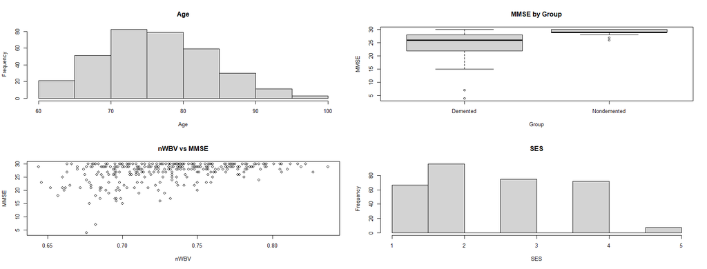

Example answer to Q32

## Command card

Everything you need for today’s questions, copied from the Day 1 tutorial. `d`, `x`, `y` and `g` are placeholders for your own objects. Entries marked **(new)** did not appear on the Day 1 card.

| Need | Pattern |
| --- | --- |
| Store values | `x <- c(27, 28, 30)` |
| Import | `d <- read.csv("data/alzheimer_data.csv", header = TRUE)` |
| First look | `head(d)`; `dim(d)`; `nrow(d)`; `ncol(d)`; `names(d)`; `str(d)`; `summary(d)` |
| What type is a column? | `class(d$Age)`; `str(d)` |
| Distinct values of a column | `unique(d$CDR)` **(new)** |
| One column / one group | `d$MMSE`; `d$MMSE[d$Group == "Demented"]` |
| Rows and columns | `d[rows, cols]`; `d[d$MMSE < 20, ]`; `d[d$Group == "Demented" & d$sex == "M", ]` |
| Counts | `table(d$Group)`; `table(d$sex, d$Group)` |
| Missing values | `sum(is.na(d$SES))`; `colSums(is.na(d))` **(new)**; `mean(x, na.rm = TRUE)`; `x[!is.na(x)]` |
| Add a column | `d$is_senior <- d$Age > 80` |
| Summaries | `mean(x)`; `median(x)`; `sd(x)`; `min(x)`; `max(x)`; `range(x)` **(new)**; `quantile(x)`; `IQR(x)` |
| Round a number | `round(x, digits = 2)` **(new)** |
| Summaries per group | `tapply(d$Age, d$Group, mean)`; `tapply(d$Age, d$Group, sd)` |
| Every column at once | `sapply(d, class)`; `sapply(d, mean)` |
| The row with the highest / lowest value | `d[which.min(d$MMSE), ]`; `d[which.max(d$MMSE), ]` **(new)** |
| Distribution plots | `hist(x)`; `boxplot(y ~ g, data = d)`; `stripchart(y ~ g, data = d, vertical = TRUE, method = "jitter", add = TRUE, pch = 16)` |
| Bar chart of group means | `barplot(tapply(d$MMSE, d$Group, mean))` **(new)** |
| Scatterplot | `plot(d$nWBV, d$MMSE, pch = 16)` |
| Colour points by group | `col = c("red", "blue")[factor(d$Group)]` **(new)** |
| Add a legend | `legend("topright", legend = levels(factor(d$Group)), col = c("red", "blue"), pch = 16)` **(new)** |
| Several plots in one window | `par(mfrow = c(2, 2))` **(new)** |
| Normality evidence | `qqnorm(x); qqline(x)`; `shapiro.test(x)` |
| Two groups, two vectors | `t.test(x, y)`; `wilcox.test(x, y, exact = FALSE)` |
| Two groups, one column + one grouping column | `t.test(MMSE ~ Group, data = d)`; `wilcox.test(MMSE ~ Group, data = d)` **(new)** |
| Paired | `t.test(after, before, paired = TRUE)` |
| More than two groups | `oneway.test(y ~ g, data = d)`; `kruskal.test(y ~ g, data = d)` |
| Association | `cor.test(x, y, method = "pearson")`; `cor.test(x, y, method = "spearman", exact = FALSE)` |
| Categories | `table(a, b)`; `chisq.test(counts)`; `chisq.test(counts)$expected`; `fisher.test(counts)` |
| Pull one number out of a test | `t.test(x, y)$p.value`; `$conf.int`; `$estimate` |
| Multiple testing | `p.adjust(p_values, method = "bonferroni")` |
| ggplot version | `ggplot(d, aes(nWBV, MMSE, colour = Group)) + geom_point()` |

## Submit your work

1. Fill in your name in the `author:` line at the top of this file.
2. **Session → Restart R**, then click **Knit**. If the HTML appears without errors, your analysis is reproducible.
3. Open the knitted `day2_mmse_tasks.html`, check that your answers, figures and explanations are all there.
4. Upload the HTML file to **Canvas** before the end of the day.

Work individually; discussing the questions in groups is permitted, but the code and explanations you submit must be your own.